# Customer integration and operational performance: The mediating role of information quality

Brian Detweiler and John Zhuang  
October 19, 2017

### Agenda

- Introduction
- Theoretical background & hypotheses development
- Research methodology
- Results
- Discussion
- Conclusion

### Introduction

- Mediating role of information quality
- Direct relationship between customer integration and operational performance
- Questionnaire on 228 Ireland manufacturing companies

### Terminology

- Supply chain (SC) integration
- Customer integration
- Operational performance
- Social capital theory

### Two Questions

1. to what extent is the relationship between customer integration and operational performance mediated by information quality
2. to what extent does customer integration associate directly with operational performance (partial mediation)

### Theoretical Background & Hypothesis Development

- Social capital theory and SCM
- Social structures have a valuable asset in themselves
- Enable firms to exchange assets
- Social actors obtain benefits from investing in social structures.

### Theoretical Background & Hypothesis Development

- Customer integration and information quality
- Critical competency for successful integration efforts
- Customer driven
- Build long-term relationships
- Right information

### Theoretical Background & Hypothesis Development

- Information quality and operational performance
- Quality
- Delivery
- Flexibility
- Cost

### Theoretical Background & Hypothesis Development

- Customer integration and operational performance
- Directly associated with each other
- Partial mediation effect

### Sampling and Data Collection

- Cross-sectional design (as opposed to longitudinal) using quantitative questionnaire
- Questionnaire sent to 655 Irish companies
- Offered benchmark score relative to industry as incentive for response
- 236 questionnaires returned, with 228 usable (36% response rate)

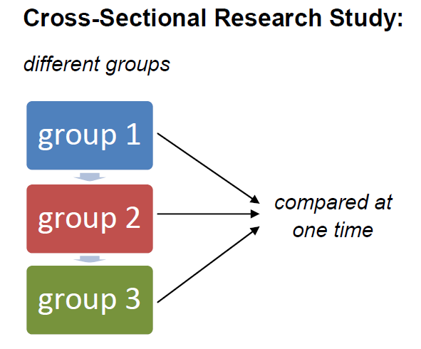

### Why Ireland?

- Considered a small but open and trade-dependent economy
  - Changed rapidly from agricultural economy one of the highest GDP/capita in Europe
- Growing trend to outsource labor intensive activities
  - Makes effective use of SC a key issue to success
- Economic crisis requires more efficient use of resources
  - Justifies strategic role of SCM

### Non-Response Bias

- Respondent answers tend to differ greatly from non-respondent views
  - Respondents in later waves compare similarly to non-respondents due to incentives
  - Chi-square tests show all responses to be >> 0.01
    - Suggests non-responses should not be a concern

### Common Method Bias

- Spurious variance attributed to measurement method rather than objectives being measured
  - Ex. A survey form with an interface unfamiliar to some, but familiar to others
- Harmon's single factor test through exploratory factor analysis (EFA is a data driven approach)
  - First factor explained 28.5% of the variance (<< 50%)

### Common Method Bias

- Confirmatory factor analysis (CFA is a deductive approach)
  - Model and hypothesis is specified a priori

  | RMSEA | Model Fit | CFA | Measurement model |
  | --- | --- | --- | --- |
  | < 0.05 | Good Fit |  |  |
  | 0.05 - 0.08 | Acceptable Fit |  | **0.062** |
  | > 0.08 | Bad Fit | **0.14** |  |

  - Other model fit measures also fell within acceptable range

### Data Validation for Model Suitability

- Data tested for linearity
  - Plotted standardized residuals (\( \epsilon \)) against standardized predictions (\( \hat{y} \))
- Data tested for multicollinearity
  - Correlation coefficients << 0.70
  - Variance Inflation Factor (VIF) 1.314 < 5
  - Suggests no multicollinearity

### Validation and Measurement Scales

- Step 1: Content Validitiy
  - Draft questionnaire pre-tested with academics and practitioners
  - Made suggested modifications and pilot tested with subset of population

### Validation

- Step 2: Construct Validitiy
  - Discriminant validity
    - Unidimensionality
    - Ex. “Math test should only measure mathematical abilities not English grammar”
    - EFA with principal axis factoring (similar to PCA)
    - Varimax (orthogonal) rotation
    - Extracting factors with eigenvalues greater than 1.0

### Validation

- Step 3: Reliability
  - Cronbach's alpha
    - all above (or close to) 0.7 indicating high reliability

### Validation - Factors and their reliability

- Based on Cronbach's alpha

  | Cronbach's alpha | Internal consistency | Customer Integration | Information Quality | Quality | Delivery | Flexibility | Cost |
  | --- | --- | --- | --- | --- | --- | --- | --- |
  | \( 0.9 \leq \alpha \) | Excellent |  |  |  |  |  |  |
  | \( 0.8 < \alpha < 0.9 \) | Good |  |  |  | *0.816* |  | *0.810* |
  | \( 0.7 < \alpha < 0.8 \) | Acceptable | *0.751* | *0.782* | *0.704* |  |  |  |
  | \( 0.6 < \alpha < 0.7 \) | Questionable |  |  |  |  | *0.682* |  |
  | \( 0.5 < \alpha < 0.6 \) | Poor |  |  |  |  |  |  |
  | \( \alpha < 0.5 \) | Unacceptable |  |  |  |  |  |  |

### Measurement - Customer Integration

- Scales: 1 = strongly agree … 5 = strongly disagree
- *Customer integration* measured on
  - Q: *We frequently interact with this customer to set reliability, responsiveness, and other standards for us*
  - Q: *We frequently measure and evaluate this customer satisfaction*
  - Q: *We frequently determine this customer future expectations*
  - Q: *We inform this customer of changing needs*
  - Q: *This customer shares proprietary information with us*

### Measurement - Information Quality

- Scales: 1 = strongly agree … 5 = strongly disagree
- 5 IQ dimensions measured:
- Q: *Information exchange between customer and us is **accurate***
- Q: *Information exchange between customer and us is **complete***
- Q: *Information exchange between customer and us is **adequate***
- Q: *Information exchange between customer and us is **reliable***
- Q: *Information exchange between customer and us is **relevant***

### Measurement - Operational Performance

- Scales: 1 = Superior … 5 = Poor
- Each had their own separate questions
- **Quality**
- **Delivery**
- **Flexibility**
- **Cost**

### Modelling

- Applied Ordinary Least Squares (OLS) regression
- 4 different models - one for each operational performance dimension - 3 steps each
  - Step 1. Control variables (*industry type*) and predictor variable (*customer integration*) regressed against mediator variable (*IQ*)
  - Step 2. Predictor variable (*customer integration*) regressed against each dependent variable (*Quality, Delivery, Flexibility, Cost*)
  - Step 3. Regressed dependent variables on both mediator (*IQ*) and predictor variables (*Quality, Delivery, Flexibility, Cost*)

### Results

- Step 1: CI positively associated with IQ
- Step 2: CI positively associated with quality, delivery, flexibility, and cost
- Step 3: Upon including IQ, CI continued to be significantly related to quality
  - Support:
    - Partial H1a (CI \( \xrightarrow[]{\text{IQ}} \) quality), full H2a (CI \( \rightarrow \) quality)
    - Partial H1b (CI \( \xrightarrow[]{\text{IQ}} \) delivery), full H2b (CI \( \rightarrow \) delivery)
    - Partial H1c (CI \( \xrightarrow[]{\text{IQ}} \) flexibility), full H2c (CI \( \rightarrow \) flexibility)
    - Full H1d (CI \( \xrightarrow[]{\text{IQ}} \) cost), none H2d (CI \( \nrightarrow \) cost)

### Conclusion

- CI practices (frequent interactions with customers) \( \rightarrow \) quality, delivery, and flexibility improve
- To pursue quality, delivery and flexibility, IQ alone is less effective
  - Need to complement IQ with CI
- IQ translates CI into cost improvement